# **Introduction**

Traditional portfolio construction, rooted in modern portfolio theory, is often a static, single-period process that relies heavily on accurate estimates of expected returns and covariance matrices parameters that are notoriously difficult to forecast (Kolm and Ritter 4). In dynamic, real-world markets, this approach can fail to adapt to new information, leaving portfolios vulnerable. Reinforcement learning (RL) offers a paradigm shift, reframing portfolio selection as a sequential, adaptive decision-making problem where an agent learns an optimal policy through direct interaction with the market environment.

This project explores a specific subset of RL, the multi-armed bandit (MAB) framework, to address the challenge of dynamic stock selection. MAB models are well-suited for problems that require balancing the exploration-exploitation trade-off: the choice between exploiting assets that have performed well in the past and exploring other assets to discover potentially higher future returns (Sutton and Barto). By treating each stock as an "arm" that delivers a "reward" (its daily return), the MAB framework allows an agent to develop a selection strategy over time without requiring complex market forecasts (Huo and Fu 2).

The work is structured in a series of steps designed to build, test, and evaluate MAB strategies. First, we will collect and prepare historical daily stock returns from a period of high volatility (September-October 2008) (Step 3). We will then compute and visualize the correlation structure of the market during this period (Step 4). The core of the project involves implementing and applying two canonical MAB policies Upper-Confidence-Bound (UCB) and Epsilon-Greedy to the 2008 dataset (Steps 6 & 8). Finally, we will test the robustness of these algorithms by re-running the simulations on a more recent crisis period, the COVID-19 crash of March-April 2020, and analyzing the difference in performance (Steps 10 & 11).

The primary objectives are to: (1) Implement UCB and Epsilon-Greedy algorithms to actively select single stocks on a daily basis; (2) Quantitatively compare the performance of these two learning strategies against each other and a naive benchmark during the 2008 financial crisis; and (3) Evaluate the stability and effectiveness of these policies by applying them to the different market dynamics of the 2020 pandemic crash.

By testing these adaptive agents in two distinct, real-world crisis scenarios, this project provides a practical evaluation of simple reinforcement learning strategies for dynamic portfolio management, assessing their potential as alternatives to traditional allocation models in volatile markets.

# **Step 1: Review of Huo and Fu’s Article**

For this step, a selective reading of Huo and Fu's 2017 paper, *Risk-aware multi-armed bandit problem with application to portfolio selection*, was conducted to extract the core methodology for applying reinforcement learning to financial portfolio management. The analysis focused specifically on the problem formulation and the proposed combined sequential portfolio selection algorithm, designated as *Algorithm 1*, while omitting detailed proofs and the preliminary asset filtering methodology as per the project guidelines.

The paper frames the investment challenge as a *Model 1: Sequential portfolio selection problem*, where an agent iteratively allocates capital among a basket of $K$ assets over $N$ trading days to maximize rewards. The central contribution of the paper is a hybrid algorithm that constructs a balanced portfolio by combining a reward-seeking component with a risk-management component at each time step $t$.

The reward-seeking element is driven by the Upper-Confidence-Bound (UCB1) policy, a classic multi-armed bandit algorithm designed to efficiently solve the exploration--exploitation dilemma. The UCB1 policy selects a single asset, $I_{t}^{*}$, that maximizes an upper confidence bound on the expected return, according to the formula:

$$ I_{t}^{*} \stackrel{\text { def }}{=} \begin{cases} t & \text{if } t \leq K, \\ \arg \max\limits_{i \in [1, \ldots, K]} \ \bar{R}_{i}(t) + \sqrt{\tfrac{2 \log t}{T_{i}(t-1)}} & \text{otherwise,} \end{cases} $$

where $\bar{R}_{i}(t)$ is the historical average return for asset $i$, and $T_{i}(t-1)$ is the number of times asset $i$ has been previously selected. This selection results in a single-asset portfolio, denoted as $\omega_{t}^{M}$.

Concurrently, the risk-management component seeks to construct a portfolio, $\omega_{t}^{C}$, that minimizes the *Conditional Value-at-Risk (CVaR)*, a coherent risk measure that quantifies the expected loss in the tail of the return distribution. Since the true return distribution is unknown, the algorithm approximates the CVaR optimization by using historical and observed returns to solve for the portfolio that minimizes the following function:

$$ \tilde{F}_{\gamma}(u, \alpha, t) \stackrel{\text{ def }}{=} \alpha + \frac{1}{(\delta + t - 1)(1-\gamma)} \left[ \sum_{s=1}^{\delta} \left[ -u^{\top} H_{s} - \alpha \right]^{+} + \sum_{s=1}^{t-1} \left[ -u^{\top} R_{s} - \alpha \right]^{+} \right], $$

where $H_s$ are historical returns and $R_s$ are observed returns.

Finally, *Algorithm 1* combines these two sub-portfolios using a risk-preference parameter, $\lambda \in [0,1]$, to form the final portfolio, $\omega_{t}^{*}$:

$$ \omega_{t}^{*} = \lambda \, \omega_{t}^{M} + (1-\lambda) \, \omega_{t}^{C}. $$

This parameter explicitly controls the trade-off between maximizing reward (as $\lambda \to 1$) and minimizing risk (as $\lambda \to 0$), allowing the investor to tailor the strategy to their specific risk tolerance and market view. The key takeaway from the reading is this novel synthesis of a bandit algorithm for exploitation with a formal risk measure for protection, creating a dynamic and risk-aware portfolio selection framework.

# **Step 2: Pseudocode for Model 1: Sequential Portfolio Selection**

To solve this question, we implement the foundational framework of "Model 1: Sequential Portfolio Selection Problem" (Huo and Fu 3). This initial step establishes a passive, non-learning benchmark against which more advanced reinforcement learning strategies will be compared. The methodology involves data preprocessing and a simulation of a static investment strategy.

First, the raw daily closing prices, $P_{i,t}$ for each asset $i$ at time $t$, are converted into daily logarithmic returns, $R_{i,t}$. This is essential for time-series analysis and is calculated using the formula (Huo and Fu 3): $$R_{i,t} = \ln\left(\frac{P_{i,t}}{P_{i,t-1}}\right)$$ The dataset is then divided into two distinct periods: an initial historical window of $\delta$ days, used for preliminary analysis, and a subsequent investment horizon of $N$ days, over which the simulation runs (Huo and Fu 3). For this step, a basket of $K$ assets is arbitrarily selected from the available tickers`

The core of the simulation is an iterative loop that proceeds for each day $t$ from $1$ to $N$. In this baseline model, a simple, equally-weighted portfolio strategy is employed. The portfolio weight vector, $\omega_t$, which represents the capital allocation for day $t$, is defined as (Huo and Fu 3): $$ \omega_t = \begin{bmatrix} \omega_{1,t} \\ \omega_{2,t} \\ \vdots \\ \omega_{K,t} \end{bmatrix} \quad \text{where} \quad \omega_{i,t} = \frac{1}{K} \quad \text{for all } i \in \{1, \dots, K\} $$

```
ALGORITHM: SequentialPortfolioSelection

INPUT:
  - A set of all available assets (stocks), `A`.
  - The total number of time steps (trading days) for the investment horizon, `T`.
  - A historical dataset of returns for an initial period, `delta`.

INITIALIZE:
  1.  Process the full dataset to get a time series of daily return vectors, `R`.
  2.  Split `R` into two periods:
      - `historical_returns` = returns from day 1 to `delta`.
      - `investment_returns` = returns from day `delta + 1` to `T`.
  3.  Use `historical_returns` to filter and select a smaller basket of `K` assets for investment. Let this be `investment_basket`.
  4.  Create an empty "Knowledge Base" to store the agent's experience. This will hold the history of actions, observed returns, and rewards.

PROCEDURE:
  // Main loop that runs for each trading day in the investment horizon
  FOR t = 1 TO length(investment_returns):

    // Step 1: Choose an action (portfolio weights)
    // The agent uses its current Knowledge Base to decide on a portfolio.
    // This is where a specific bandit policy (like UCB or Epsilon-Greedy) would be applied.
    ω_t = CHOOSE_PORTFOLIO_WEIGHTS(investment_basket, Knowledge_Base)

    // Step 2: Observe the outcome from the market
    // Get the actual return vector for the assets in the basket for the current day t.
    r_t = get_returns_for_day(investment_returns, t, investment_basket)

    // Step 3: Calculate the reward
    // The reward for the day is the dot product of the chosen weights and the observed returns.
    reward_t = ω_t ⋅ r_t

    // Step 4: Update the agent's knowledge
    // The agent learns from the outcome by updating its Knowledge Base with the
    // action taken, the returns observed, and the reward received.
    UPDATE_KNOWLEDGE_BASE(Knowledge_Base, ω_t, r_t, reward_t)

  END FOR
```

```python
import pandas as pd
import numpy as np

# =============================================================================
# 1) DATA LOADING & DATE FIX
# =============================================================================

sheet_id = "12d6YzmR1eDi-XXAHJe73xPc6ciitdp8I"
csv_url  = f"https://docs.google.com/spreadsheets/d/{sheet_id}/export?format=csv"

df_prices = pd.read_csv(csv_url)

if "Date" not in df_prices.columns:
    df_prices.rename(columns={df_prices.columns[0]: "Date"}, inplace=True)

df_prices["Date"] = pd.to_datetime(df_prices["Date"], errors="coerce")


# =============================================================================
# 2) HELPER FUNCTIONS
# =============================================================================

def calculate_log_returns(price_data):
    """
    Calculates daily logarithmic returns from prices DataFrame.
    Returns a DataFrame with a 'Date' column and one log-return column per ticker.
    """
    prices = price_data.set_index("Date").sort_index()
    for col in prices.columns:
        prices[col] = pd.to_numeric(prices[col], errors="coerce")
    log_ret = np.log(prices / prices.shift(1)).reset_index()
    return log_ret

def filter_assets_for_investment(historical_returns, K):
    """
    Placeholder: pick the first K tickers (excludes 'Date').
    """
    assets = historical_returns.columns.drop("Date").tolist()
    basket = assets[:K]
    print(f"Selected {K} assets for basket: {basket}")
    return basket

def choose_portfolio_weights(investment_basket, knowledge_base):
    """
    Placeholder: equal-weight allocation over the basket.
    """
    num = len(investment_basket)
    return np.full(num, 1.0 / num)

def update_knowledge_base(knowledge_base, day, action, reward, returns, basket):
    """
    Store day, weights, reward, and each ticker's return.
    """
    out = {
        "Day": day,
        "Weights": list(np.round(action, 4)),
        "Daily Reward": float(np.round(reward, 6)),
        "Asset Returns": {tkr: float(ret) for tkr, ret in zip(basket, returns)}
    }
    knowledge_base["history"].append(out)
    return knowledge_base


# =============================================================================
# 3) MAIN SIMULATION
# =============================================================================

def sequential_portfolio_selection(price_data, K, delta):

    all_returns = calculate_log_returns(price_data)

    # Historical window: skip first NaN row
    historical = all_returns.iloc[1 : delta + 1]
    # Investment window: from delta+1 onward
    investment = all_returns.iloc[delta + 1 :].reset_index(drop=True)
    N = len(investment)
    print(f"Parameters: δ={delta}, N_invest={N}, K={K}\n")

    # Step 1: choose assets
    basket = filter_assets_for_investment(historical, K)

    # Initialize knowledge_base (store basket plus history)
    knowledge_base = {
        "basket": basket,
        "history": []
    }
    cum_reward = 0.0

    # Step 2: daily loop
    for t in range(N):
        day = t + 1
        ω = choose_portfolio_weights(basket, knowledge_base)
        ret_vec = investment[basket].iloc[t].values
        r_t = np.dot(ω, ret_vec)
        cum_reward += r_t

        knowledge_base = update_knowledge_base(
            knowledge_base, day, ω, r_t, ret_vec, basket
        )

        if day == 1 or day % 10 == 0 or day == N:
            print(
                f"Day {day}/{N} | "
                f"Daily Reward = {r_t:.3f} | "
                f"Cumulative = {cum_reward:.3f}"
            )

    print(f"Final Cumulative Reward over {N} days: {cum_reward:.3f}")
    return cum_reward, knowledge_base


# =============================================================================
# 4) EXECUTION & RESULTS DATAFRAME
# =============================================================================

if __name__ == "__main__":
    DELTA    = 10  # initial historical days
    K_ASSETS = 5   # number of tickers to hold

    final_reward, final_kb = sequential_portfolio_selection(
        price_data=df_prices,
        K=K_ASSETS,
        delta=DELTA
    )


    basket = final_kb["basket"]
    records = final_kb["history"]

    flat_rows = []
    for rec in records:
        row = {
            "Day": rec["Day"],
            "Daily Reward": rec["Daily Reward"]
        }

        for tkr in basket:
            row[tkr] = rec["Asset Returns"][tkr]
        flat_rows.append(row)

    summary_df = pd.DataFrame(flat_rows).round(3)

    print("\n" + "-" * 60)
    print("Table 1: Sequential Portfolio Selection Results Summary (4dp)")
    print("-" * 60)
    print(summary_df.to_string(index=False))
    print("-" * 60)
```

```
Parameters: δ=10, N_invest=33, K=5

Selected 5 assets for basket: ['JPM', 'WFC', 'BAC', 'C', 'GS']
Day 1/33 | Daily Reward = -0.104 | Cumulative = -0.104
Day 10/33 | Daily Reward = 0.120 | Cumulative = 0.121
Day 20/33 | Daily Reward = 0.098 | Cumulative = -0.012
Day 30/33 | Daily Reward = 0.094 | Cumulative = -0.171
Day 33/33 | Daily Reward = 0.055 | Cumulative = -0.144
Final Cumulative Reward over 33 days: -0.144

------------------------------------------------------------
Table 1: Sequential Portfolio Selection Results Summary (4dp)
------------------------------------------------------------
 Day  Daily Reward    JPM    WFC    BAC      C     GS
   1        -0.104 -0.130 -0.044 -0.083 -0.116 -0.150
   2         0.090  0.119  0.101  0.117  0.171 -0.058
   3         0.166  0.155  0.073  0.203  0.215  0.184
   4        -0.092 -0.143 -0.123 -0.093 -0.031 -0.072
   5        -0.005 -0.006 -0.029 -0.025 -0.001  0.035
   6         0.001 -0.001  0.003 -0.007 -0.053  0.062
   7         0.029  0.071 -0.004  0.039  0.023  0.019
   8         0.063  0.104  0.089  0.066  0.037  0.018
   9        -0.146 -0.163 -0.115 -0.193 -0.127 -0.134
  10         0.120  0.130  0.121  0.146  0.145  0.059
  11         0.058  0.061 -0.022  0.086  0.115  0.050
  12        -0.026  0.004 -0.043 -0.047 -0.022 -0.022
  13        -0.077 -0.083 -0.017 -0.053 -0.204 -0.027
  14        -0.044 -0.042 -0.027 -0.068 -0.053 -0.032
  15        -0.145 -0.112 -0.095 -0.304 -0.139 -0.075
  16        -0.020 -0.001  0.042 -0.073 -0.051 -0.018
  17        -0.112 -0.069 -0.158 -0.119 -0.108 -0.109
  18         0.036  0.127  0.038  0.061  0.087 -0.132
  19         0.100  0.008  0.071  0.088  0.110  0.223
  20         0.098 -0.031  0.098  0.152  0.167  0.102
  21        -0.078 -0.056 -0.005 -0.108 -0.137 -0.083
  22         0.012  0.051  0.016  0.018 -0.021 -0.007
  23        -0.035 -0.029 -0.056 -0.043 -0.066  0.017
  24         0.032  0.033  0.005  0.049  0.014  0.061
  25        -0.018 -0.023  0.013 -0.018 -0.062 -0.001
  26        -0.056 -0.067 -0.042 -0.056 -0.063 -0.053
  27        -0.008  0.018  0.001  0.015 -0.016 -0.058
  28        -0.064 -0.066 -0.013 -0.088 -0.077 -0.078
  29        -0.036 -0.041 -0.003 -0.026 -0.034 -0.078
  30         0.094  0.101  0.111  0.114  0.134  0.007
  31        -0.030 -0.052 -0.071 -0.031 -0.038  0.043
  32         0.002  0.052 -0.008  0.020  0.015 -0.069
  33         0.055  0.092  0.067  0.059  0.040  0.015
------------------------------------------------------------
```

# **Step 3 a): Data for 15 financial institutions**

```python
import pandas as pd
import numpy as np

# =============================================================================
# 1) DATA LOADING & PREPARATION (Self-Contained)
# =============================================================================

sheet_id = "12d6YzmR1eDi-XXAHJe73xPc6ciitdp8I"
csv_url  = f"https://docs.google.com/spreadsheets/d/{sheet_id}/export?format=csv"

df_prices = pd.read_csv(csv_url)

# Ensure the first column is named "Date"
if "Date" not in df_prices.columns:
    df_prices.rename(columns={df_prices.columns[0]: "Date"}, inplace=True)

df_prices["Date"] = pd.to_datetime(df_prices["Date"], errors="coerce")

# =============================================================================
# 2) DATA COLLECTION FOR MEMBER A (Financial Stocks)
# =============================================================================

def collect_financial_data(full_price_df: pd.DataFrame) -> pd.DataFrame:
    """
    Collects price data for 15 specified financial institutions
    from the full price DataFrame.
    """
    financial_tickers = [
        'JPM', 'WFC', 'BAC', 'C', 'GS',
        'USB', 'MS', 'KEY', 'PNC', 'COF',
        'AXP','PRU','SCHW','BBT','STI'
    ]

    columns_to_collect = ['Date'] + financial_tickers
    df_financials = full_price_df[columns_to_collect].copy()

    print("Table 2: Data Collection for 15 Financial Institutions")
    print("-" * 120)
    print(f"Successfully collected data for {len(financial_tickers)} tickers:")
    print(financial_tickers)
    print("-" * 120)

    return df_financials

# =============================================================================
# 3) EXECUTION AND DISPLAY
# =============================================================================

if __name__ == "__main__":
    # Collect the data
    df_financial_institutions = collect_financial_data(df_prices)

    # Round all numeric columns to 3 decimal places
    df_financial_institutions = df_financial_institutions.round(3)

    # Display first 5 rows with 3-decimal formatting
    print("\nDisplaying first 5 rows of the collected financial data:")
    print("-" * 120)
    print(
        df_financial_institutions
        .head()
        .to_string(float_format="%.3f", index=False)
    )
    print("-" * 120)

    # Display last 5 rows with 3-decimal formatting
    print("\nDisplaying last 5 rows of the collected financial data:")
    print("-" * 120)
    print(
        df_financial_institutions
        .tail()
        .to_string(float_format="%.3f", index=False)
    )
    print("-" * 120)
```

```
Table 2: Data Collection for 15 Financial Institutions
------------------------------------------------------------------------------------------------------------------------
Successfully collected data for 15 tickers:
['JPM', 'WFC', 'BAC', 'C', 'GS', 'USB', 'MS', 'KEY', 'PNC', 'COF', 'AXP', 'PRU', 'SCHW', 'BBT', 'STI']
------------------------------------------------------------------------------------------------------------------------

Displaying first 5 rows of the collected financial data:
------------------------------------------------------------------------------------------------------------------------
      Date    JPM    WFC    BAC       C      GS    USB     MS    KEY    PNC    COF    AXP    PRU   SCHW    BBT    STI
2008-09-02 38.990 31.210 32.630 191.100 165.320 32.370 41.300 12.600 73.440 44.920 40.630 77.440 24.180 30.820 43.560
2008-09-03 39.710 31.010 32.960 196.100 167.610 32.950 42.170 12.710 74.120 45.660 40.910 79.500 24.210 31.170 45.000
2008-09-04 37.910 29.670 30.600 183.000 160.900 31.650 40.340 11.920 72.750 43.330 38.750 76.960 23.560 30.030 43.560
2008-09-05 39.600 31.200 32.230 190.700 163.240 32.740 41.360 12.970 74.290 44.710 39.400 78.740 24.090 31.820 45.420
2008-09-08 41.550 33.560 34.730 203.200 169.730 33.940 43.270 13.740 76.780 48.730 40.520 84.920 25.220 34.270 50.930
------------------------------------------------------------------------------------------------------------------------

Displaying last 5 rows of the collected financial data:
------------------------------------------------------------------------------------------------------------------------
      Date    JPM    WFC    BAC       C     GS    USB     MS    KEY    PNC    COF    AXP    PRU   SCHW    BBT    STI
2008-10-27 34.000 30.830 20.530 117.300 92.880 28.820 13.730  9.920 58.630 34.400 23.080 32.250 15.530 32.200 35.340
2008-10-28 37.600 34.460 23.020 134.100 93.570 30.820 15.200 11.860 65.440 39.900 25.470 36.500 17.700 35.990 39.940
2008-10-29 35.710 32.110 22.320 129.100 97.660 29.030 14.760 12.150 62.820 37.850 25.210 35.250 17.450 33.960 38.560
2008-10-30 37.620 31.840 22.780 131.100 91.110 28.800 16.090 12.300 64.470 38.120 26.060 28.870 18.540 34.340 37.900
2008-10-31 41.250 34.050 24.170 136.500 92.500 29.810 17.470 12.410 66.670 39.120 27.500 30.000 19.120 35.850 40.140
------------------------------------------------------------------------------------------------------------------------
```

# **Step 3b: Data Collection for 15 Non-Financial Institutions**

```python
import pandas as pd
import numpy as np

# =============================================================================
# 1) DATA LOADING & PREPARATION
# =============================================================================

sheet_id = "12d6YzmR1eDi-XXAHJe73xPc6ciitdp8I"
csv_url = f"https://docs.google.com/spreadsheets/d/{sheet_id}/export?format=csv"

df_prices = pd.read_csv(csv_url)

# Ensure the first column is named "Date"
if "Date" not in df_prices.columns:
    df_prices.rename(columns={df_prices.columns[0]: "Date"}, inplace=True)

df_prices["Date"] = pd.to_datetime(df_prices["Date"], errors="coerce")


# =============================================================================
# 2) DATA COLLECTION FOR MEMBER B (Non-Financial Stocks)
# =============================================================================

def collect_non_financial_data(full_price_df: pd.DataFrame) -> pd.DataFrame:
    """
    Collects price data for 15 specified non-financial institutions
    from the full price DataFrame.
    """
    all_tickers = [
        'JPM', 'WFC', 'BAC', 'C', 'GS', 'USB', 'MS', 'KEY', 'PNC',
        'COF', 'AXP', 'PRU', 'SCHW', 'BBT', 'STI', 'KR', 'PFE',
        'XOM', 'WMT', 'DAL', 'CSCO', 'HCP', 'EQIX', 'DUK', 'NFLX',
        'GE', 'APA', 'F', 'REGN', 'CMS'
    ]

    financial_tickers = [
        'JPM', 'WFC', 'BAC', 'C', 'GS', 'USB', 'MS', 'KEY', 'PNC',
        'COF', 'AXP', 'PRU', 'SCHW', 'BBT', 'STI'
    ]

    non_financial_tickers = [
        ticker for ticker in all_tickers
        if ticker not in financial_tickers
    ]

    columns_to_collect = ['Date'] + non_financial_tickers
    df_non_financials = full_price_df[columns_to_collect].copy()

    print("-" * 110)
    print(f"Successfully collected data for {len(non_financial_tickers)} non-financial tickers:")
    print(non_financial_tickers)
    print("-" * 110)

    return df_non_financials


# =============================================================================
# 3) EXECUTION AND DISPLAY
# =============================================================================

if __name__ == "__main__":

    # collect data
    df_non_financial_institutions = collect_non_financial_data(df_prices)

    # round all numeric columns to 3 decimal places
    df_non_financial_institutions = df_non_financial_institutions.round(3)

    # display first 5 rows with 3-decimal formatting
    print("\nTable 3: Data Collection for 15 Non-Financial Institutions (First 5 Rows)")
    print("-" * 110)
    print(
        df_non_financial_institutions
        .head()
        .to_string(float_format="%.3f", index=False)
    )
    print("-" * 110)

    # display last 5 rows with 3-decimal formatting
    print("\nDisplaying last 5 rows of the collected non-financial data")
    print("-" * 110)
    print(
        df_non_financial_institutions
        .tail()
        .to_string(float_format="%.3f", index=False)
    )
    print("-" * 110)
```

```
--------------------------------------------------------------------------------------------------------------
Successfully collected data for 15 non-financial tickers:
['KR', 'PFE', 'XOM', 'WMT', 'DAL', 'CSCO', 'HCP', 'EQIX', 'DUK', 'NFLX', 'GE', 'APA', 'F', 'REGN', 'CMS']
--------------------------------------------------------------------------------------------------------------

Table 3: Data Collection for 15 Non-Financial Institutions (First 5 Rows)
--------------------------------------------------------------------------------------------------------------
      Date     KR    PFE    XOM    WMT   DAL   CSCO    HCP   EQIX    DUK  NFLX     GE     APA     F   REGN    CMS
2008-09-02 13.900 19.170 77.320 59.650 9.170 23.750 32.896 80.950 52.020 4.406 28.530 106.340 4.510 20.580 13.610
2008-09-03 13.895 19.200 78.020 59.790 9.110 23.310 32.778 80.150 51.360 4.416 28.570 107.480 4.570 21.800 13.450
2008-09-04 13.625 18.670 76.140 59.780 8.960 22.280 31.457 77.500 51.870 4.267 27.700 110.030 4.390 20.380 13.470
2008-09-05 13.435 18.510 75.620 60.740 8.810 22.260 31.239 77.490 51.930 4.237 27.880 111.430 4.410 19.070 13.340
2008-09-08 13.650 19.140 76.770 62.000 8.590 23.370 32.013 77.510 53.610 4.307 29.090 109.770 4.550 18.900 13.750
--------------------------------------------------------------------------------------------------------------

Displaying last 5 rows of the collected non-financial data
--------------------------------------------------------------------------------------------------------------
      Date     KR    PFE    XOM    WMT    DAL   CSCO    HCP   EQIX    DUK  NFLX     GE    APA     F   REGN    CMS
2008-10-27 12.745 16.390 66.090 49.670  7.660 16.090 23.825 51.670 47.160 2.563 17.730 64.360 2.030 15.460  9.670
2008-10-28 13.370 17.820 74.860 55.170  8.160 18.310 27.295 56.910 50.040 2.939 19.490 71.500 2.150 16.750 10.270
2008-10-29 13.250 17.190 74.650 55.020  7.990 17.870 26.749 59.610 48.720 3.109 19.200 74.810 2.160 17.430 10.170
2008-10-30 13.735 17.860 75.050 54.750  9.550 17.790 27.268 62.650 50.490 3.254 19.350 78.950 2.280 18.140 10.540
2008-10-31 13.730 17.710 74.120 55.810 10.980 17.770 27.250 62.420 49.140 3.540 19.510 82.330 2.190 19.300 10.250
--------------------------------------------------------------------------------------------------------------
```

# **Step 3c: Combine Data and Compute Daily Returns**

To solve this question, first, the task of combining the data was accomplished by loading the full dataset containing all 30 stocks into a single pandas DataFrame. This DataFrame serves as the "suitable Python time series data structure" required by the project instructions. Next, we computed the daily returns for all 30 series. Following standard practice for financial time-series analysis, we calculated the *daily logarithmic returns*. If we denote the price of a stock $i$ on day $t$ as $P_{i,t}$, the logarithmic return $R_{i,t}$ is calculated with the formula: $$R_{i,t} = \ln\left(\frac{P_{i,t}}{P_{i,t-1}}\right)$$ This was implemented in Python by taking the natural logarithm of the ratio of the current day's price to the previous day's price for each stock. The final output is a new DataFrame containing the calculated daily log returns for the entire investment period, which will be used for all subsequent analysis.

```python
import pandas as pd
import numpy as np

# =============================================================================
# 1) DATA LOADING & PREPARATION
# =============================================================================
sheet_id = "12d6YzmR1eDi-XXAHJe73xPc6ciitdp8I"
csv_url = f"https://docs.google.com/spreadsheets/d/{sheet_id}/export?format=csv"

df_prices = pd.read_csv(csv_url)

if "Date" not in df_prices.columns:
    df_prices.rename(columns={df_prices.columns[0]: "Date"}, inplace=True)

df_prices["Date"] = pd.to_datetime(df_prices["Date"], errors="coerce")


# =============================================================================
# 2) COMPUTE DAILY RETURNS FOR ALL 30 STOCKS
# =============================================================================

def compute_daily_log_returns(full_price_df):
    """
    Computes the daily logarithmic returns for all 30 stock series.

    Args:
        full_price_df (pd.DataFrame): The complete DataFrame with prices for all 30 stocks.

    Returns:
        pd.DataFrame: A new DataFrame containing the daily log returns.
                      The first row will contain NaN values.
    """
    prices_indexed = full_price_df.set_index('Date')

    prices_numeric = prices_indexed.apply(pd.to_numeric, errors='coerce')

    log_returns = np.log(prices_numeric / prices_numeric.shift(1))

    return log_returns.reset_index()

# =============================================================================
# 3) EXECUTION AND DISPLAY
# =============================================================================

if __name__ == "__main__":

    df_daily_returns = compute_daily_log_returns(df_prices)

    df_daily_returns_rounded = df_daily_returns.round(3)


    print("Table 4: Daily Logarithmic Returns for All 30 Stocks")
    print("-" * 220)
    print("Displaying the first 5 rows of the daily returns data")
    print("-" * 220)
    print(df_daily_returns_rounded.head().to_string())
    print("-" * 220)
    print("\nDisplaying the last 5 rows of the daily returns data")
    print("-" * 220)
    print(df_daily_returns_rounded.tail().to_string())
    print("-" * 220)
```

```
Table 4: Daily Logarithmic Returns for All 30 Stocks
----------------------------------------------------------------------------------------------------------------------------------------------------------------------------------------------------------------------------
Displaying the first 5 rows of the daily returns data
----------------------------------------------------------------------------------------------------------------------------------------------------------------------------------------------------------------------------
        Date    JPM    WFC    BAC      C     GS    USB     MS    KEY    PNC    COF    AXP    PRU   SCHW    BBT    STI     KR    PFE    XOM    WMT    DAL   CSCO    HCP   EQIX    DUK   NFLX     GE    APA      F   REGN    CMS
0 2008-09-02    NaN    NaN    NaN    NaN    NaN    NaN    NaN    NaN    NaN    NaN    NaN    NaN    NaN    NaN    NaN    NaN    NaN    NaN    NaN    NaN    NaN    NaN    NaN    NaN    NaN    NaN    NaN    NaN    NaN    NaN
1 2008-09-03  0.018 -0.006  0.010  0.026  0.014  0.018  0.021  0.009  0.009  0.016  0.007  0.026  0.001  0.011  0.033 -0.000  0.002  0.009  0.002 -0.007 -0.019 -0.004 -0.010 -0.013  0.002  0.001  0.011  0.013  0.058 -0.012
2 2008-09-04 -0.046 -0.044 -0.074 -0.069 -0.041 -0.040 -0.044 -0.064 -0.019 -0.052 -0.054 -0.032 -0.027 -0.037 -0.033 -0.020 -0.028 -0.024 -0.000 -0.017 -0.045 -0.041 -0.034  0.010 -0.034 -0.031  0.023 -0.040 -0.067  0.001
3 2008-09-05  0.044  0.050  0.052  0.041  0.014  0.034  0.025  0.084  0.021  0.031  0.017  0.023  0.022  0.058  0.042 -0.014 -0.009 -0.007  0.016 -0.017 -0.001 -0.007 -0.000  0.001 -0.007  0.006  0.013  0.005 -0.066 -0.010
4 2008-09-08  0.048  0.073  0.075  0.063  0.039  0.036  0.045  0.058  0.033  0.086  0.028  0.076  0.046  0.074  0.114  0.016  0.033  0.015  0.021 -0.025  0.049  0.024  0.000  0.032  0.016  0.042 -0.015  0.031 -0.009  0.030
----------------------------------------------------------------------------------------------------------------------------------------------------------------------------------------------------------------------------

Displaying the last 5 rows of the daily returns data
----------------------------------------------------------------------------------------------------------------------------------------------------------------------------------------------------------------------------
         Date    JPM    WFC    BAC      C     GS    USB     MS    KEY    PNC    COF    AXP    PRU   SCHW    BBT    STI     KR    PFE    XOM    WMT    DAL   CSCO    HCP   EQIX    DUK   NFLX     GE    APA      F   REGN    CMS
39 2008-10-27 -0.041 -0.003 -0.026 -0.034 -0.078 -0.022 -0.185 -0.020 -0.004 -0.026 -0.041 -0.066 -0.048 -0.002  0.007 -0.035 -0.011 -0.044 -0.034 -0.081 -0.014 -0.042 -0.025  0.006 -0.055 -0.006 -0.080  0.010 -0.044 -0.039
40 2008-10-28  0.101  0.111  0.114  0.134  0.007  0.067  0.102  0.179  0.110  0.148  0.099  0.124  0.131  0.111  0.122  0.048  0.084  0.125  0.105  0.063  0.129  0.136  0.097  0.059  0.137  0.095  0.105  0.057  0.080  0.060
41 2008-10-29 -0.052 -0.071 -0.031 -0.038  0.043 -0.060 -0.029  0.024 -0.041 -0.053 -0.010 -0.035 -0.014 -0.058 -0.035 -0.009 -0.036 -0.003 -0.003 -0.021 -0.024 -0.020  0.046 -0.027  0.056 -0.015  0.045  0.005  0.040 -0.010
42 2008-10-30  0.052 -0.008  0.020  0.015 -0.069 -0.008  0.086  0.012  0.026  0.007  0.033 -0.200  0.061  0.011 -0.017  0.036  0.038  0.005 -0.005  0.178 -0.004  0.019  0.050  0.036  0.046  0.008  0.054  0.054  0.040  0.036
43 2008-10-31  0.092  0.067  0.059  0.040  0.015  0.034  0.082  0.009  0.034  0.026  0.054  0.038  0.031  0.043  0.057 -0.000 -0.008 -0.012  0.019  0.140 -0.001 -0.001 -0.004 -0.027  0.084  0.008  0.042 -0.040  0.062 -0.028
----------------------------------------------------------------------------------------------------------------------------------------------------------------------------------------------------------------------------
```

# **Step 4: 30 by 30 correlation matrix.**

To solve this question, the first step was data processing. We began by loading the historical price data for the 30 tickers. From these prices, we calculated the daily log returns for each stock. The log return $r_t$ on a given day $t$ is calculated from the price $P_t$ on that day and the price $P_{t-1}$ on the previous day, using the formula:

$$r_t = \ln\left(\frac{P_t}{P_{t-1}}\right)$$

This transformation is standard in financial analysis as it results in a time-additive series that approximates the percentage change in price.

Once the daily log returns were calculated, we computed the 30x30 Pearson correlation matrix, denoted as $\rho$. Each element $\rho_{ij}$ in the matrix represents the correlation coefficient between the log returns of stock $i$ and stock $j$. The formula for the Pearson correlation coefficient between two variables $X$ and $Y$ is:

$$\rho_{X,Y} = \frac{\text{cov}(X,Y)}{\sigma_X \sigma_Y}$$

where $\text{cov}(X,Y)$ is the covariance between $X$ and $Y$, and $\sigma_X$ and $\sigma_Y$ are their respective standard deviations.

**Discussion on Sorting Criteria**

To make the correlation heatmap insightful, the arrangement of stocks is crucial. A random or alphabetical order would obscure the patterns. Our chosen criteria for sorting the 30 stocks is to group them by their economic sector. This approach is based on the rationale that companies operating in the same sector (e.g., Financials, Technology, Consumer Staples) are subject to similar macroeconomic forces, industry-specific news, and market sentiment. Consequently, their stock prices tend to move together, resulting in higher correlations among them.

By sorting the correlation matrix according to these predefined sectors, we can visually cluster stocks with similar business models. This method transforms the heatmap from a simple matrix of numbers into a clear map of the market's structure, allowing for easy identification of highly correlated blocks and the relationships between different sectors. This structured approach is superior to purely algorithmic sorting (like hierarchical clustering alone) because it grounds the analysis in the fundamental economic relationships between the companies.

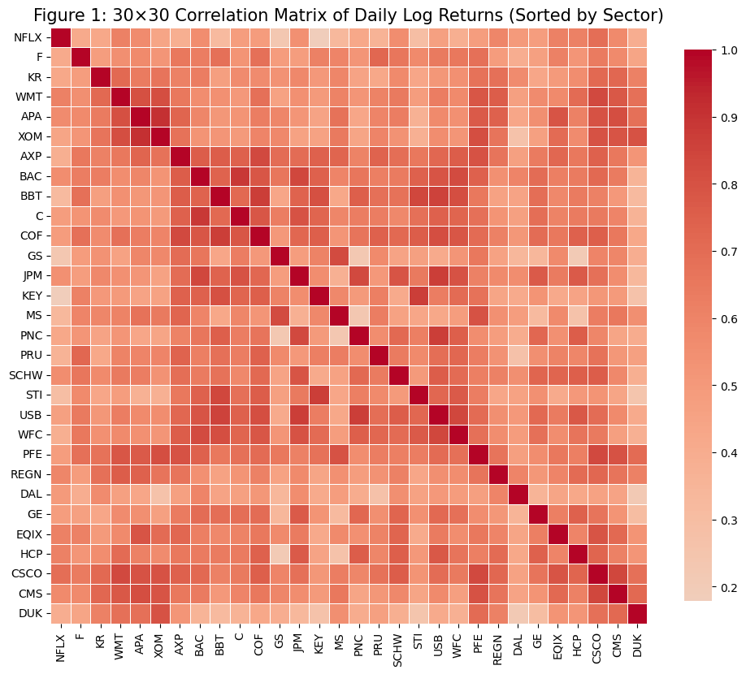

```python
import pandas as pd
import numpy as np
import seaborn as sns
import matplotlib.pyplot as plt


csv_url = (
    "https://docs.google.com/spreadsheets/"
    "d/12d6YzmR1eDi-XXAHJe73xPc6ciitdp8I/"
    "export?format=csv"
)
df_prices = pd.read_csv(csv_url)
df_prices.rename(columns={df_prices.columns[0]: "Date"}, inplace=True)
df_prices["Date"] = pd.to_datetime(df_prices["Date"], errors="coerce")

# Daily log returns
prices = df_prices.set_index("Date").apply(pd.to_numeric, errors="coerce")
df_returns = np.log(prices / prices.shift(1)).dropna(how="all")

# 2) Sector assignments for all 30 tickers
sector_map = {
    # Financials
    "JPM":"Financials", "WFC":"Financials", "BAC":"Financials",
    "C":"Financials",   "GS":"Financials",  "USB":"Financials",
    "MS":"Financials",  "KEY":"Financials", "PNC":"Financials",
    "COF":"Financials", "AXP":"Financials", "PRU":"Financials",
    "SCHW":"Financials","BBT":"Financials","STI":"Financials",
    # Non-financials
    "KR":"Consumer Staples",   "WMT":"Consumer Staples",
    "DAL":"Industrials",       "GE":"Industrials",
    "XOM":"Energy",            "APA":"Energy",
    "CSCO":"Technology",       "NFLX":"Communication Services",
    "PFE":"Healthcare",        "REGN":"Healthcare",
    "EQIX":"Real Estate",      "HCP":"Real Estate",
    "DUK":"Utilities",         "CMS":"Utilities",
    "F":"Consumer Discretionary"
}


df_sectors = (
    pd.DataFrame.from_dict(sector_map, orient="index", columns=["Sector"])
      .reset_index()
      .rename(columns={"index":"Ticker"})
      .sort_values(["Sector","Ticker"])
)
sorted_tickers = df_sectors["Ticker"].tolist()


corr = df_returns.corr()
corr_sorted = corr.reindex(index=sorted_tickers, columns=sorted_tickers)


plt.figure(figsize=(10,10))
sns.heatmap(
    corr_sorted,
    cmap="coolwarm",
    center=0,
    linewidths=0.5,
    square=True,
    cbar_kws={"shrink":0.7}
)
plt.title("Figure 1: 30×30 Correlation Matrix of Daily Log Returns (Sorted by Sector)", fontsize=15)
plt.xticks(rotation=90)
plt.yticks(rotation=0)
plt.tight_layout()
plt.savefig("correlation_heatmap_sorted.png", dpi=300)
```